# Plotting and Visualization in R

PS239T

18 March, 2020

## 1) Set Up

### 1.1. Setup environment

```r
# remove all objects
rm(list=ls())

# check working directory
getwd()
```

```
## [1] "C:/Users/Julia/OneDrive/Documents/Berkeley/2020-01_Spring/PS239T_Spring2020/09_r-analysis-visualization/01_analysis"
```

```r
# Unload all packages
library(pacman)
pacman::p_unload(all)
```

```
## The following packages have been unloaded:
## pacman
```

```r
# Add packages
pacman::p_load(
  tidyverse, #ggplot, dplyr, readr, etc.
  magrittr, #better piping
  viridis, #great colors
  MASS, #boston dataset
  broom, #tidy() function
  sandwich, lmtest, #robust se
  skimr #summarising data
)
```

### 1.2. View dataset

For the following examples, we will use the Boston dataset, which comes with the `MASS` package. Boston is a dataset of Housing Values in Suburbs of Boston.

This data frame contains the following columns:

- crim - per capita crime rate by town.
- zn - proportion of residential land zoned for lots over 25,000 sq.ft.
- indus - proportion of non-retail business acres per town.
- chas - Charles River dummy variable (= 1 if tract bounds river; 0 otherwise).
- nox - nitrogen oxides concentration (parts per 10 million).
- rm - average number of rooms per dwelling.
- age - proportion of owner-occupied units built prior to 1940.
- dis - weighted mean of distances to five Boston employment centres.
- rad - index of accessibility to radial highways.
- tax - full-value property-tax rate per $10,000.
- ptratio - pupil-teacher ratio by town.
- black - 1000(Bk - 0.63)^2 where Bk is the proportion of blacks by town.
- lstat - lower status of the population (percent).
- medv - median value of owner-occupied homes in $1000s.

```r
data(Boston)

skimr::skim(MASS::Boston)
```

Data summary

| Name | MASS::Boston |
| --- | --- |
| Number of rows | 506 |
| Number of columns | 14 |
| _______________________ |  |
| Column type frequency: |  |
| numeric | 14 |
| ________________________ |  |
| Group variables | None |

**Variable type: numeric**

| skim_variable | n_missing | complete_rate | mean | sd | p0 | p25 | p50 | p75 | p100 | hist |
| --- | --- | --- | --- | --- | --- | --- | --- | --- | --- | --- |
| crim | 0 | 1 | 3.61 | 8.60 | 0.01 | 0.08 | 0.26 | 3.68 | 88.98 | ▇▁▁▁▁ |
| zn | 0 | 1 | 11.36 | 23.32 | 0.00 | 0.00 | 0.00 | 12.50 | 100.00 | ▇▁▁▁▁ |
| indus | 0 | 1 | 11.14 | 6.86 | 0.46 | 5.19 | 9.69 | 18.10 | 27.74 | ▇▆▁▇▁ |
| chas | 0 | 1 | 0.07 | 0.25 | 0.00 | 0.00 | 0.00 | 0.00 | 1.00 | ▇▁▁▁▁ |
| nox | 0 | 1 | 0.55 | 0.12 | 0.38 | 0.45 | 0.54 | 0.62 | 0.87 | ▇▇▆▅▁ |
| rm | 0 | 1 | 6.28 | 0.70 | 3.56 | 5.89 | 6.21 | 6.62 | 8.78 | ▁▂▇▂▁ |
| age | 0 | 1 | 68.57 | 28.15 | 2.90 | 45.02 | 77.50 | 94.07 | 100.00 | ▂▂▂▃▇ |
| dis | 0 | 1 | 3.80 | 2.11 | 1.13 | 2.10 | 3.21 | 5.19 | 12.13 | ▇▅▂▁▁ |
| rad | 0 | 1 | 9.55 | 8.71 | 1.00 | 4.00 | 5.00 | 24.00 | 24.00 | ▇▂▁▁▃ |
| tax | 0 | 1 | 408.24 | 168.54 | 187.00 | 279.00 | 330.00 | 666.00 | 711.00 | ▇▇▃▁▇ |
| ptratio | 0 | 1 | 18.46 | 2.16 | 12.60 | 17.40 | 19.05 | 20.20 | 22.00 | ▁▃▅▅▇ |
| black | 0 | 1 | 356.67 | 91.29 | 0.32 | 375.38 | 391.44 | 396.23 | 396.90 | ▁▁▁▁▇ |
| lstat | 0 | 1 | 12.65 | 7.14 | 1.73 | 6.95 | 11.36 | 16.96 | 37.97 | ▇▇▅▂▁ |
| medv | 0 | 1 | 22.53 | 9.20 | 5.00 | 17.02 | 21.20 | 25.00 | 50.00 | ▂▇▅▁▁ |

### 1.3. Visualization set up

```r
# Change default plot dimensions
knitr::opts_chunk$set(fig.width=12, fig.height=8)

# Load themes
source("../06_setup/visualisation.R")
```

2. PLOT CIs

## 2.1. Unadjusted OLS errors

First, generate regression results and save dataframe with estimat, se, and ci variables.

```r
# Save linear model results
l1 <- lm(medv ~ crim + zn + indus + chas + rm + age + dis + rad + tax + ptratio + black + lstat, Boston)
summary(l1)
```

```
##
## Call:
## lm(formula = medv ~ crim + zn + indus + chas + rm + age + dis +
##     rad + tax + ptratio + black + lstat, data = Boston)
##
## Residuals:
##     Min      1Q  Median      3Q     Max
## -17.040  -2.831  -0.823   1.573  27.220
##
## Coefficients:
##              Estimate Std. Error t value Pr(>|t|)
## (Intercept) 23.499999   4.364331   5.385 1.13e-07 ***
## crim        -0.098898   0.033486  -2.953 0.003293 **
## zn           0.048706   0.014003   3.478 0.000549 ***
## indus       -0.054945   0.060543  -0.908 0.364563
## chas         2.552290   0.878930   2.904 0.003851 **
## rm           3.991551   0.424714   9.398  < 2e-16 ***
## age         -0.015599   0.013001  -1.200 0.230790
## dis         -1.214013   0.195327  -6.215 1.09e-09 ***
## rad          0.262181   0.067033   3.911 0.000105 ***
## tax         -0.013639   0.003828  -3.563 0.000402 ***
## ptratio     -0.752176   0.126074  -5.966 4.64e-09 ***
## black        0.010247   0.002734   3.748 0.000199 ***
## lstat       -0.540980   0.051643 -10.475  < 2e-16 ***
## ---
## Signif. codes:  0 '***' 0.001 '**' 0.01 '*' 0.05 '.' 0.1 ' ' 1
##
## Residual standard error: 4.844 on 493 degrees of freedom
## Multiple R-squared:  0.7292, Adjusted R-squared:  0.7226
## F-statistic: 110.6 on 12 and 493 DF,  p-value: < 2.2e-16
```

```r
# Tidy output for plotting
coef1 <- broom::tidy(l1, conf.int = TRUE) %>% print()
```

```
## # A tibble: 13 x 7
##    term        estimate std.error statistic  p.value conf.low conf.high
##    <chr>          <dbl>     <dbl>     <dbl>    <dbl>    <dbl>     <dbl>
##  1 (Intercept)  23.5      4.36        5.38  1.13e- 7 14.9      32.1
##  2 crim         -0.0989   0.0335     -2.95  3.29e- 3 -0.165    -0.0331
##  3 zn            0.0487   0.0140      3.48  5.49e- 4  0.0212    0.0762
##  4 indus        -0.0549   0.0605     -0.908 3.65e- 1 -0.174     0.0640
##  5 chas          2.55     0.879       2.90  3.85e- 3  0.825     4.28
##  6 rm            3.99     0.425       9.40  2.07e-19  3.16      4.83
##  7 age          -0.0156   0.0130     -1.20  2.31e- 1 -0.0411    0.00995
##  8 dis          -1.21     0.195      -6.22  1.09e- 9 -1.60     -0.830
##  9 rad           0.262    0.0670      3.91  1.05e- 4  0.130     0.394
## 10 tax          -0.0136   0.00383    -3.56  4.02e- 4 -0.0212   -0.00612
## 11 ptratio      -0.752    0.126      -5.97  4.64e- 9 -1.00     -0.504
## 12 black         0.0102   0.00273     3.75  1.99e- 4  0.00488   0.0156
## 13 lstat        -0.541    0.0516    -10.5   2.55e-23 -0.642    -0.440
```

Here is one way to generate a CI plot.

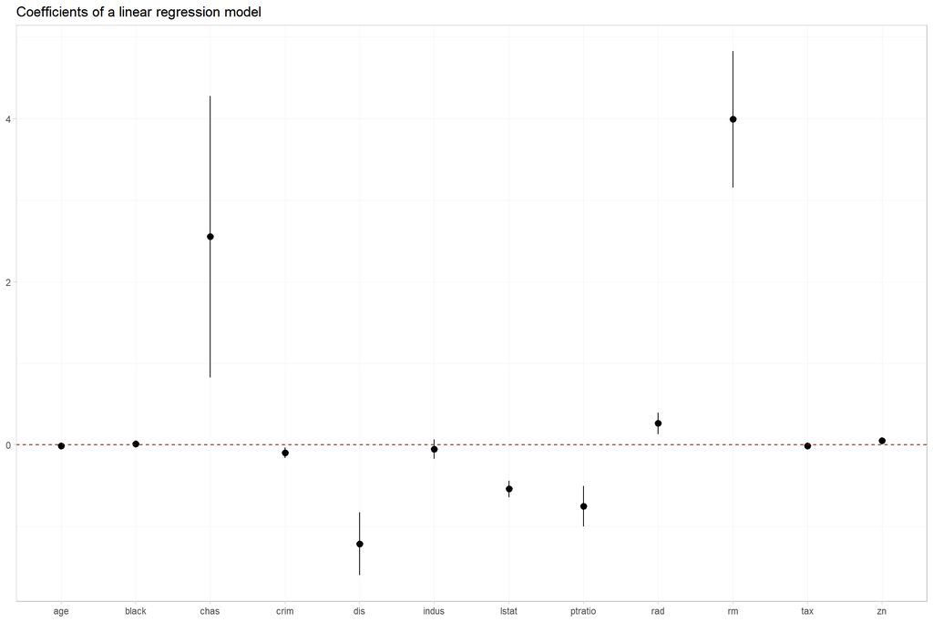

```r
# Plot coef
coef1 %>%
  # remove intercept
  filter(term != "(Intercept)") %>%
  # plot
  ggplot(aes(x=term, y=estimate)) +
    geom_point() +
    geom_pointrange(aes(ymin = conf.low, ymax = conf.high)) +
    geom_hline(aes(yintercept=0), colour="#990000", linetype="dashed") +
    labs(title = "Coefficients of a linear regression model") +
    ylab(NULL) + xlab(NULL) +
    theme_ed
```

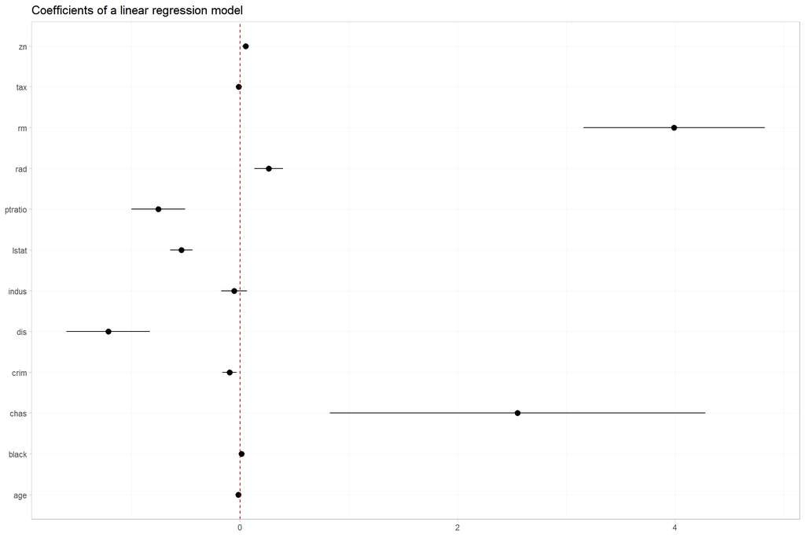

```r
# We can also flip the axis
coef1 %>%
  # remove intercept
  filter(term != "(Intercept)") %>%
  # plot
  ggplot(aes(x=term, y=estimate)) +
    geom_point() +
    geom_pointrange(aes(ymin = conf.low, ymax = conf.high)) +
    geom_hline(aes(yintercept=0), colour="#990000", linetype="dashed") +
    labs(title = "Coefficients of a linear regression model") +
    ylab(NULL) + xlab(NULL) +
    theme_ed +
    coord_flip()
```

Here is a second way to generate CI plots. I have also included code for plotting multiple CIs (e.g. 95% and 90% CIs).

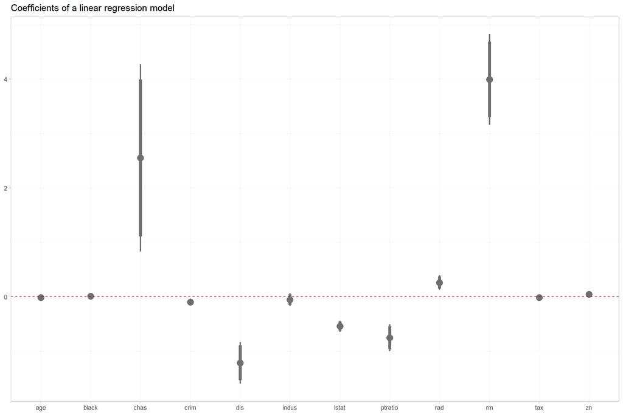

```r
# Point + CI size
  pt_size <- 4 #12 large; 6 small
  ln_size <- 1 #3 large, 1 small

# Plot coef
coef1 %>%
  # remove intercept
  filter(term != "(Intercept)") %>%
  # plot
  ggplot(aes(x=term, y=estimate)) +
    geom_point(size=pt_size, colour="gray43") +
    geom_errorbar(aes(ymin=estimate-1.96*std.error, ymax=estimate+1.96*std.error),
                  colour="gray43", width=0, size=ln_size) +
    geom_errorbar(aes(ymin=estimate-1.64*std.error, ymax=estimate+1.64*std.error),
                  colour="gray43", width=0, size=ln_size+1) +
    geom_hline(aes(yintercept=0), colour="#990000", linetype="dashed") +
    labs(title = "Coefficients of a linear regression model") +
    ylab(NULL) + xlab(NULL) +
    theme_ed
```

First, generate regression results and save dataframe with estimate and se variables.

```r
# Save linear model results
lm1 <- lm(medv ~ crim + zn + indus + chas + rm + age + dis + rad + tax + ptratio + black + lstat, Boston)
summary(lm1)
```

```
##
## Call:
## lm(formula = medv ~ crim + zn + indus + chas + rm + age + dis +
##     rad + tax + ptratio + black + lstat, data = Boston)
##
## Residuals:
##     Min      1Q  Median      3Q     Max
## -17.040  -2.831  -0.823   1.573  27.220
##
## Coefficients:
##              Estimate Std. Error t value Pr(>|t|)
## (Intercept) 23.499999   4.364331   5.385 1.13e-07 ***
## crim        -0.098898   0.033486  -2.953 0.003293 **
## zn           0.048706   0.014003   3.478 0.000549 ***
## indus       -0.054945   0.060543  -0.908 0.364563
## chas         2.552290   0.878930   2.904 0.003851 **
## rm           3.991551   0.424714   9.398  < 2e-16 ***
## age         -0.015599   0.013001  -1.200 0.230790
## dis         -1.214013   0.195327  -6.215 1.09e-09 ***
## rad          0.262181   0.067033   3.911 0.000105 ***
## tax         -0.013639   0.003828  -3.563 0.000402 ***
## ptratio     -0.752176   0.126074  -5.966 4.64e-09 ***
## black        0.010247   0.002734   3.748 0.000199 ***
## lstat       -0.540980   0.051643 -10.475  < 2e-16 ***
## ---
## Signif. codes:  0 '***' 0.001 '**' 0.01 '*' 0.05 '.' 0.1 ' ' 1
##
## Residual standard error: 4.844 on 493 degrees of freedom
## Multiple R-squared:  0.7292, Adjusted R-squared:  0.7226
## F-statistic: 110.6 on 12 and 493 DF,  p-value: < 2.2e-16
```

```r
# Save heteroskedasticity consistent (HC) standard errors
robust1 <- lm1 %>%
  lmtest::coeftest(., vcov(., type="HC3")) %>%
  tidy() %>%
  print()
```

```
## # A tibble: 13 x 5
##    term        estimate std.error statistic  p.value
##    <chr>          <dbl>     <dbl>     <dbl>    <dbl>
##  1 (Intercept)  23.5      4.36        5.38  1.13e- 7
##  2 crim         -0.0989   0.0335     -2.95  3.29e- 3
##  3 zn            0.0487   0.0140      3.48  5.49e- 4
##  4 indus        -0.0549   0.0605     -0.908 3.65e- 1
##  5 chas          2.55     0.879       2.90  3.85e- 3
##  6 rm            3.99     0.425       9.40  2.07e-19
##  7 age          -0.0156   0.0130     -1.20  2.31e- 1
##  8 dis          -1.21     0.195      -6.22  1.09e- 9
##  9 rad           0.262    0.0670      3.91  1.05e- 4
## 10 tax          -0.0136   0.00383    -3.56  4.02e- 4
## 11 ptratio      -0.752    0.126      -5.97  4.64e- 9
## 12 black         0.0102   0.00273     3.75  1.99e- 4
## 13 lstat        -0.541    0.0516    -10.5   2.55e-23
```

Here is one way to generate a CI plot.

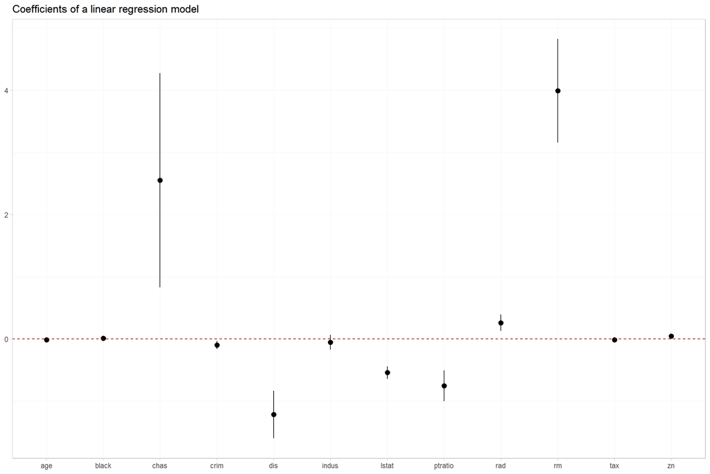

```r
# Plot coef
robust1 %>%
  # remove intercept
  filter(term != "(Intercept)") %>%
  # plot
  ggplot(aes(x=term, y=estimate)) +
    geom_point() +
    geom_pointrange(aes(ymin = estimate-1.96*std.error,
                        ymax = estimate+1.96*std.error)) +
    geom_hline(aes(yintercept=0), colour="#990000", linetype="dashed") +
    labs(title = "Coefficients of a linear regression model") +
    ylab(NULL) + xlab(NULL) +
    theme_ed #+ coord_flip()
```

Here is a second way to generate CI plots. I have also included code for plotting multiple CIs (e.g. 95% and 90% CIs).

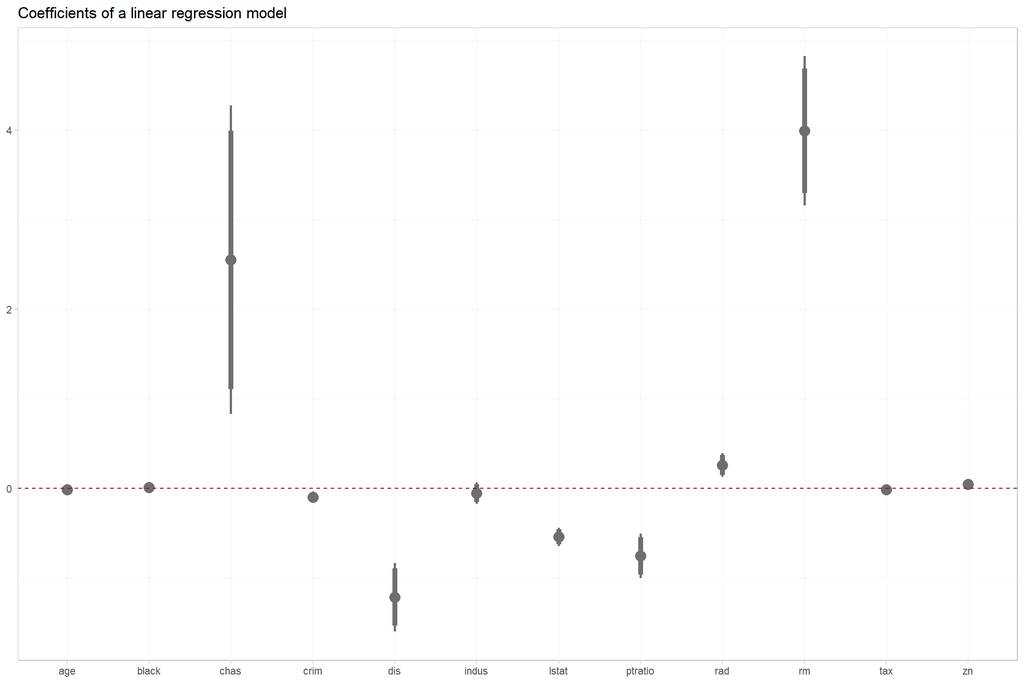

```r
# Point + CI size
  pt_size <- 4 #12 large; 6 small
  ln_size <- 1 #3 large, 1 small

# Plot coef
robust1 %>%
  # remove intercept
  filter(term != "(Intercept)") %>%
  # plot
  ggplot(aes(x=term, y=estimate)) +
    geom_point(size=pt_size, colour="gray43") +
    geom_errorbar(aes(ymin=estimate-1.96*std.error, ymax=estimate+1.96*std.error),
                  colour="gray43", width=0, size=ln_size) +
    geom_errorbar(aes(ymin=estimate-1.64*std.error, ymax=estimate+1.64*std.error),
                  colour="gray43", width=0, size=ln_size+1) +
    geom_hline(aes(yintercept=0), colour="#990000", linetype="dashed") +
    labs(title = "Coefficients of a linear regression model") +
    ylab(NULL) + xlab(NULL) +
    theme_ed
```